# 🏥 강남언니 입점 업체 vs 미입점 업체 비교 분석

분석 일시: 2026-01-20 00:32 | 데이터: 병원명 기준 매칭 (188건 입점)

## 📊 분석 결과 요약

총 병원 수

1,153

건

입점 업체

188

16.3%

미입점 업체

965

83.7%

## Part 1: 강남언니 입점 업체 특징 분석

### 1.1 기본 프로필

| 지표 | 값 |
| --- | --- |
| 총 병원 수 | **188건** |
| 평균 병상 수 | 0.52개 |
| 평균 의사 수 | 0.84명 |
| 평균 직원 수 | 0.00명 |
| 평균 수술실 수 | 0.57개 |

### 1.2 의사 유형 분포

| 유형 | 병원 수 | 비율 |
| --- | --- | --- |
| 일반의 | 97건 | 51.6% |
| 전문의 | 91건 | 48.4% |

#### 💡 인사이트

- 전문의 vs 일반의 비율이 거의 **1:1**
- 전문의 비율(48.4%)이 전체 평균(37.4%)보다 높음
- 강남언니 플랫폼이 **전문의 병원을 선호**하는 경향

### 1.3 지역 분포 (TOP 5)

| 순위 | 행정동 | 병원 수 | 비율 |
| --- | --- | --- | --- |
| 1 | **신사동** | 68건 | 36.2% |
| 2 | **역삼동** | 47건 | 25.0% |
| 3 | **논현동** | 44건 | 23.4% |
| 4 | 청담동 | 14건 | 7.4% |
| 5 | 삼성동 | 8건 | 4.3% |

#### 💡 인사이트

- **신사동이 압도적 1위** (36.2%)
- 상위 3개 동(신사동, 역삼동, 논현동)이 **84.6% 차지**
- 강남역/신논현 상권에 입점 업체 집중

## Part 2: 입점 vs 미입점 업체 비교 분석

### 2.1 규모 비교

| 지표 | 입점 | 미입점 | 차이 |
| --- | --- | --- | --- |
| 평균 병상 수 | 0.52개 | 2.42개 | -1.90개 (-78.7%) |
| 평균 의사 수 | 0.84명 | 0.79명 | +0.05명 (+6.3%) |
| 평균 직원 수 | 0.00명 | 0.09명 | -0.09명 (-100%) |
| 평균 수술실 수 | 0.57개 | 0.24개 | **+0.33개 (+137.5%)** |

### 2.2 전문의 비율 비교

| 구분 | 입점 | 미입점 | 차이 |
| --- | --- | --- | --- |
| 전문의 비율 | 48.4% | 35.2% | **+13.2%p** |

### 2.3 수술실 보유율 비교

| 구분 | 입점 | 미입점 | 차이 |
| --- | --- | --- | --- |
| 수술실 보유율 | 27.1% | 9.3% | **+17.8%p** |

#### 💡 인사이트

- 입점 업체의 수술실 보유율이 **3배 높음**
- 수술 인프라가 입점의 **가장 강력한 차별화 요소**
- 고단가 시술/수술 제공 능력이 플랫폼 성공의 핵심

## 📈 시각화 분석

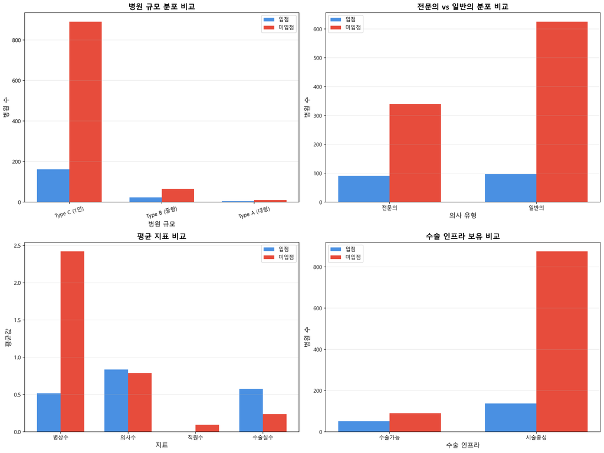

그림 1. 입점 vs 미입점 업체 종합 비교 (규모, 전문의, 평균 지표, 수술 인프라)

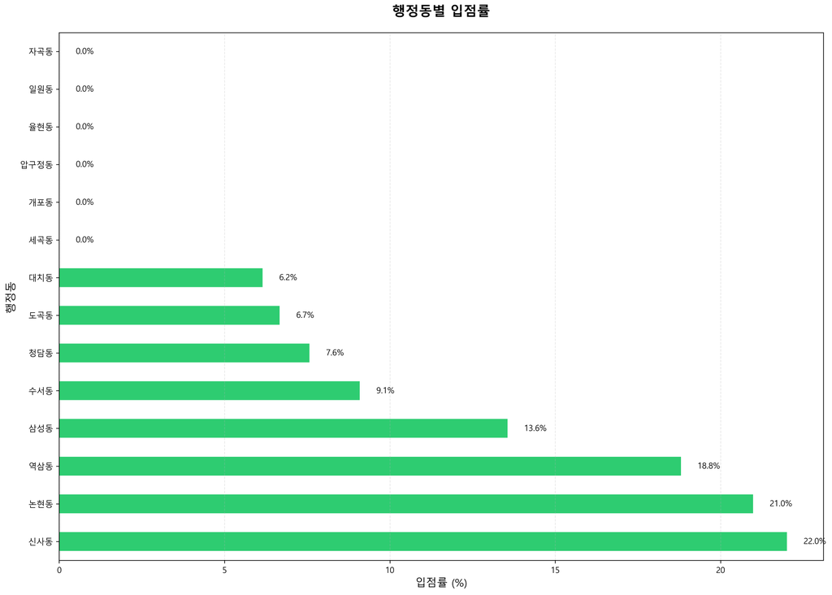

그림 2. 강남구 행정동별 입점률

### 💡 핵심 인사이트

#### 1. 입점 업체의 특징

- **✅ 강점 요소**: 전문의 자격 (48.4%), 수술실 보유 (27.1%), 강남역/신논현 상권 입지
- **📊 규모 특성**: 1인 원장 소규모 클리닉, 무병상 또는 소수 병상, 시술/수술 중심 운영

#### 2. 입점 성공 요인

| 요인 | 영향력 | 근거 |
| --- | --- | --- |
| **수술 인프라** | ⭐⭐⭐ | 입점 업체가 3배 높음 (27.1% vs 9.3%) |
| **전문의 자격** | ⭐⭐ | 입점 업체가 13.2%p 높음 |
| **입지** | ⭐⭐ | 상위 3개 동이 84.6% 차지 |
| 병원 규모 | ⭐ | 1인 원장도 충분히 입점 가능 |

## 🎯 전략적 시사점

### 1. 입점 희망 업체를 위한 가이드

#### **선택 요소**

- 병원 규모 (1인 원장도 가능)
- 병상 수 (무병상도 가능)

### 2. 플랫폼 확장 전략

#### **타겟 업체**

1. 수술실 보유 + 전문의 병원
2. 신사/역삼/논현 외 지역의 우수 병원
3. 청담동 프리미엄 병원 (현재 입점률 낮음)

#### **확장 방향**

- 수술실 미보유 시술 중심 클리닉 확대
- 일반의 병원 중 우수 업체 발굴
- 저침투 지역 공략 (대치동, 도곡동 등)

**리포트 작성**: 2026-01-20 00:32 | **분석자**: Data Analysis System | **버전**: 1.0

생성된 파일: comparison_overview_20260120_003156.png, district_penetration_rate_20260120_003156.png